# Insight and Analysis of Ford's GoBike System in the Bay Area

## Preliminary Wrangling

> This data-set is taken from Ford's GoBike system across a period of the first 10 months of 2019.

(Source) https://s3.amazonaws.com/baywheels-data/index.html

> a full 12 months was initally used - which slowed down the execution of code on my machine - 2 months (Nov-19 and Dec-19 were trimmed from the consolidated dataframe.

```python
# import all packages and set plots to be embedded inline
import numpy as np
import pandas as pd
import matplotlib.pyplot as plt
import seaborn as sb

%matplotlib inline
```

> Each data source (csv file for each month) is defined as its own unique data frame and finally consolidated into a master dataframe. The master dataframe will be the foundation for the analysis of the GoBike system.

```python
# 10 months of data are uploauded as individual dataframes

df_01 = pd.read_csv('201901-fordgobike-tripdata.csv')
print('df_01 loaded with '+str(len(df_01.index))+' rows')

df_02 = pd.read_csv('201902-fordgobike-tripdata.csv')
print('df_02 loaded with '+str(len(df_02.index))+' rows')

df_03 = pd.read_csv('201903-fordgobike-tripdata.csv')
print('df_03 loaded with '+str(len(df_03.index))+' rows')

df_04 = pd.read_csv('201904-fordgobike-tripdata.csv')
print('df_04 loaded with '+str(len(df_04.index))+' rows')

df_05 = pd.read_csv('201905-baywheels-tripdata.csv')
print('df_05 loaded with '+str(len(df_05.index))+' rows')

df_06 = pd.read_csv('201906-baywheels-tripdata.csv')
print('df_06 loaded with '+str(len(df_06.index))+' rows')

df_07 = pd.read_csv('201907-baywheels-tripdata.csv')
print('df_07 loaded with '+str(len(df_07.index))+' rows')

df_08 = pd.read_csv('201908-baywheels-tripdata.csv')
print('df_08 loaded with '+str(len(df_08.index))+' rows')

df_09 = pd.read_csv('201909-baywheels-tripdata.csv')
print('df_09 loaded with '+str(len(df_09.index))+' rows')

df_10 = pd.read_csv('201910-baywheels-tripdata.csv')
print('df_10 loaded with '+str(len(df_10.index))+' rows')
```

```
df_01 loaded with 192082 rows
df_02 loaded with 183412 rows
df_03 loaded with 256299 rows
df_04 loaded with 239111 rows
df_05 loaded with 182163 rows
```

```
df_06 loaded with 191772 rows
```

```
df_07 loaded with 258102 rows
df_08 loaded with 210563 rows
df_09 loaded with 217986 rows
df_10 loaded with 239895 rows
```

```python
# 10 months consolidated into a single dataframe

df = pd.concat([df_01,df_02,df_03,df_04,df_05,df_06,df_07,df_08,df_09,df_10], sort=True)

print('all dataframes concatenated with ' +str(len(df.index))+' rows ')
```

```
all dataframes concatenated with 2171385 rows
```

```python
df.info()
```

```
<class 'pandas.core.frame.DataFrame'>
Int64Index: 2171385 entries, 0 to 239894
Data columns (total 15 columns):
bike_id                    int64
bike_share_for_all_trip    object
duration_sec               int64
end_station_id             float64
end_station_latitude       float64
end_station_longitude      float64
end_station_name           object
end_time                   object
rental_access_method       object
start_station_id           float64
start_station_latitude     float64
start_station_longitude    float64
start_station_name         object
start_time                 object
user_type                  object
dtypes: float64(6), int64(2), object(7)
memory usage: 265.1+ MB
```

```python
df.head()
```

|  | bike_id | bike_share_for_all_trip | duration_sec | end_station_id | end_station_latitude | end_station_longitude | end_station_name | end_time | rental_access_method | start_station_id | start_station_latitude | start_station_longitude | start_station_name | start_time | user_type |
| --- | --- | --- | --- | --- | --- | --- | --- | --- | --- | --- | --- | --- | --- | --- | --- |
| 0 | 4861 | No | 80825 | 196.0 | 37.808894 | -122.256460 | Grand Ave at Perkins St | 2019-02-01 16:24:49.8640 | NaN | 229.0 | 37.775745 | -122.213037 | Foothill Blvd at 42nd Ave | 2019-01-31 17:57:44.6130 | Subscriber |
| 1 | 5506 | No | 65900 | 134.0 | 37.752428 | -122.420628 | Valencia St at 24th St | 2019-02-01 15:16:54.1730 | NaN | 4.0 | 37.785881 | -122.408915 | Cyril Magnin St at Ellis St | 2019-01-31 20:58:33.8860 | Subscriber |
| 2 | 2717 | No | 62633 | 157.0 | 37.846784 | -122.291376 | 65th St at Hollis St | 2019-02-01 11:30:46.5300 | NaN | 245.0 | 37.870139 | -122.268422 | Downtown Berkeley BART | 2019-01-31 18:06:52.9240 | Customer |
| 3 | 4557 | No | 44680 | 53.0 | 37.775946 | -122.437777 | Grove St at Divisadero | 2019-02-01 08:10:50.3180 | NaN | 85.0 | 37.770083 | -122.429156 | Church St at Duboce Ave | 2019-01-31 19:46:09.7190 | Customer |
| 4 | 2100 | No | 60709 | 28.0 | 37.787168 | -122.388098 | The Embarcadero at Bryant St | 2019-02-01 07:10:51.0650 | NaN | 16.0 | 37.794130 | -122.394430 | Steuart St at Market St | 2019-01-31 14:19:01.5410 | Customer |

```python
df.describe(include = 'all')
```

|  | bike_id | bike_share_for_all_trip | duration_sec | end_station_id | end_station_latitude | end_station_longitude | end_station_name | end_time | rental_access_method | start_station_id | start_station_latitude | start_station_longitude | start_station_name | start_time | user_type |
| --- | --- | --- | --- | --- | --- | --- | --- | --- | --- | --- | --- | --- | --- | --- | --- |
| count | 2.171385e+06 | 2079638 | 2.171385e+06 | 2.110802e+06 | 2.171385e+06 | 2.171385e+06 | 2111352 | 2171385 | 91747 | 2.112593e+06 | 2.171385e+06 | 2.171385e+06 | 2113189 | 2171385 | 2171385 |
| unique | NaN | 2 | NaN | NaN | NaN | NaN | 426 | 2166840 | 2 | NaN | NaN | NaN | 425 | 2166856 | 2 |
| top | NaN | No | NaN | NaN | NaN | NaN | San Francisco Caltrain Station 2 (Townsend St... | 2019-07-25 08:17:40 | app | NaN | NaN | NaN | Market St at 10th St | 2019-07-30 07:59:17 | Subscriber |
| freq | NaN | 1915865 | NaN | NaN | NaN | NaN | 52146 | 4 | 82832 | NaN | NaN | NaN | 39242 | 5 | 1799268 |
| mean | 2.434628e+04 | NaN | 8.092649e+02 | 1.406781e+02 | 3.776722e+01 | -1.223500e+02 | NaN | NaN | NaN | 1.438054e+02 | 3.776753e+01 | -1.223521e+02 | NaN | NaN | NaN |
| std | 1.063788e+05 | NaN | 1.899098e+03 | 1.188511e+02 | 1.731443e-01 | 4.679006e-01 | NaN | NaN | NaN | 1.195369e+02 | 1.077320e-01 | 1.613536e-01 | NaN | NaN | NaN |
| min | 1.100000e+01 | NaN | 6.000000e+01 | 3.000000e+00 | 0.000000e+00 | -1.225143e+02 | NaN | NaN | NaN | 3.000000e+00 | 0.000000e+00 | -1.225143e+02 | NaN | NaN | NaN |
| 25% | 1.830000e+03 | NaN | 3.580000e+02 | 4.300000e+01 | 3.777041e+01 | -1.224117e+02 | NaN | NaN | NaN | 4.700000e+01 | 3.777003e+01 | -1.224130e+02 | NaN | NaN | NaN |
| 50% | 3.635000e+03 | NaN | 5.700000e+02 | 1.000000e+02 | 3.778079e+01 | -1.223974e+02 | NaN | NaN | NaN | 1.040000e+02 | 3.778053e+01 | -1.223983e+02 | NaN | NaN | NaN |
| 75% | 6.383000e+03 | NaN | 8.870000e+02 | 2.380000e+02 | 3.779728e+01 | -1.222934e+02 | NaN | NaN | NaN | 2.400000e+02 | 3.779625e+01 | -1.222914e+02 | NaN | NaN | NaN |
| max | 9.994220e+05 | NaN | 8.621700e+04 | 4.820000e+02 | 4.551000e+01 | 0.000000e+00 | NaN | NaN | NaN | 4.820000e+02 | 4.551000e+01 | 0.000000e+00 | NaN | NaN | NaN |

### Data Cleaning & Wrangling

```python
df['start_time'] = pd.to_datetime(df['start_time'], errors='coerce', format='%Y-%m-%d')
df['end_time'] = pd.to_datetime(df['end_time'], errors='coerce', format='%Y-%m-%d')
```

```python
df.start_time = pd.to_datetime(df.start_time)
df.end_time = pd.to_datetime(df.end_time)
```

```python
df.start_station_id = df.start_station_id.astype(str)
df.end_station_id = df.end_station_id.astype(str)
```

#### Creating a new column for duration_hour and duration_min

```python
df['duration_min'] = df['duration_sec'] / 60
df['duration_hour'] = df['duration_sec'] / 3600
```

#### Checking bike_share_for_all_trip column

```python
df.bike_share_for_all_trip.value_counts()
```

```
No     1915865
Yes     163773
Name: bike_share_for_all_trip, dtype: int64
```

#### Checking user_type column

```python
df.user_type.value_counts()
```

```
Subscriber    1799268
Customer       372117
Name: user_type, dtype: int64
```

#### Checking start_station_id for null values

```python
x = pd.DataFrame(df[df['start_station_id']=='nan'].groupby('start_station_name')['duration_sec'].count())
x = x.reset_index()
x
```

|  | start_station_name | duration_sec |
| --- | --- | --- |
| 0 | 1st St at San Carlos Ave | 72 |
| 1 | 2nd St at Folsom St | 161 |
| 2 | 5th St at Folsom | 154 |
| 3 | 5th St at Taylor St | 7 |
| 4 | Empire St at 7th St | 30 |
| 5 | Farnam St at Fruitvale Ave | 4 |
| 6 | George St at 1st St | 46 |
| 7 | Morrison Ave at Julian St | 122 |

#### I've checked if the same start_station_name has start_station_id's in other rows.

#### It seems that for example "1st St at San Carlos Ave" is not null in all rows. So I will replace these start_station_id's.

```python
y = pd.merge(df, x, on=['start_station_name'])
y.groupby('start_station_name')['start_station_id'].min()
```

```
start_station_name
1st St at San Carlos Ave      316.0
2nd St at Folsom St            37.0
5th St at Folsom              321.0
5th St at Taylor St           289.0
Empire St at 7th St           378.0
Farnam St at Fruitvale Ave    234.0
George St at 1st St           290.0
Morrison Ave at Julian St     277.0
Name: start_station_id, dtype: object
```

#### The start_station_id's have been consistently aligned below.

```python
df.loc[df.start_station_name == '1st St at San Carlos Ave', 'start_station_id'] = '316.0'
df.loc[df.start_station_name == '2nd St at Folsom St', 'start_station_id'] = '37.0'
df.loc[df.start_station_name == '5th St at Folsom', 'start_station_id'] = '321.0'
df.loc[df.start_station_name == '5th St at Taylor St', 'start_station_id'] = '289.0'
df.loc[df.start_station_name == 'Empire St at 7th St', 'start_station_id'] = '378.0'
df.loc[df.start_station_name == 'Farnam St at Fruitvale Ave', 'start_station_id'] = '234.0'
df.loc[df.start_station_name == 'George St at 1st St', 'start_station_id'] = '290.0'
df.loc[df.start_station_name == 'Morrison Ave at Julian St', 'start_station_id'] = '277.0'
```

#### No null value left for start_station_id

```python
a = pd.DataFrame(df[df['start_station_id']=='nan'].groupby('start_station_name')['duration_sec'].count())
a
```

|  | duration_sec |
| --- | --- |
| start_station_name |  |

#### The process for identifying and removing null values is repeated for end_station_id.

```python
x = pd.DataFrame(df[df['end_station_id']=='nan'].groupby('end_station_name')['duration_sec'].count())
x = x.reset_index()

y = pd.merge(df, x, on=['end_station_name'])
y.groupby('end_station_name')['end_station_id'].min()
```

```
end_station_name
1st St at San Carlos Ave      316.0
2nd St at Folsom St            37.0
5th St at Folsom              321.0
5th St at Taylor St           289.0
Empire St at 7th St           378.0
Farnam St at Fruitvale Ave    234.0
George St at 1st St           290.0
Morrison Ave at Julian St     277.0
Name: end_station_id, dtype: object
```

```python
df.loc[df.end_station_name == '1st St at San Carlos Ave', 'end_station_id'] = '316.0'
df.loc[df.end_station_name == '2nd St at Folsom St', 'end_station_id'] = '37.0'
df.loc[df.end_station_name == '5th St at Folsom', 'end_station_id'] = '321.0'
df.loc[df.end_station_name == '5th St at Taylor St', 'end_station_id'] = '289.0'
df.loc[df.end_station_name == 'Empire St at 7th St', 'end_station_id'] = '378.0'
df.loc[df.end_station_name == 'Farnam St at Fruitvale Ave', 'end_station_id'] = '234.0'
df.loc[df.end_station_name == 'George St at 1st St', 'end_station_id'] = '290.0'
df.loc[df.end_station_name == 'Morrison Ave at Julian St', 'end_station_id'] = '277.0'
```

#### Creating additional columns regarding the date and time of the renting.

> As there is no user specific data (e.g. demograhphics such as age, nationality), my analysis will focus on the GoBike system's journey characteristics.

> For instance, I am looking to explore if there are peak user days and routes. This could lead to insight for local traffic management or reveal results indicating why GoBike is more or less used during certain days.

```python
df.start_time = pd.to_datetime(df.start_time)
df.end_time = pd.to_datetime(df.end_time)
```

```python
df['start_time_month'] = df['start_time'].dt.month.astype(int)
df['start_time_hour'] = df['start_time'].dt.hour.astype(int)
df['end_time_hour'] = df['end_time'].dt.hour.astype(int)
```

```python
df['start_time_day'] = df['start_time'].dt.strftime('%a')
```

```python
df.head()
```

|  | bike_id | bike_share_for_all_trip | duration_sec | end_station_id | end_station_latitude | end_station_longitude | end_station_name | end_time | rental_access_method | start_station_id | ... | start_station_longitude | start_station_name | start_time | user_type | duration_min | duration_hour | start_time_month | start_time_hour | end_time_hour | start_time_day |
| --- | --- | --- | --- | --- | --- | --- | --- | --- | --- | --- | --- | --- | --- | --- | --- | --- | --- | --- | --- | --- | --- |
| 0 | 4861 | No | 80825 | 196.0 | 37.808894 | -122.256460 | Grand Ave at Perkins St | 2019-02-01 16:24:49.864 | NaN | 229.0 | ... | -122.213037 | Foothill Blvd at 42nd Ave | 2019-01-31 17:57:44.613 | Subscriber | 1347.083333 | 22.451389 | 1 | 17 | 16 | Thu |
| 1 | 5506 | No | 65900 | 134.0 | 37.752428 | -122.420628 | Valencia St at 24th St | 2019-02-01 15:16:54.173 | NaN | 4.0 | ... | -122.408915 | Cyril Magnin St at Ellis St | 2019-01-31 20:58:33.886 | Subscriber | 1098.333333 | 18.305556 | 1 | 20 | 15 | Thu |
| 2 | 2717 | No | 62633 | 157.0 | 37.846784 | -122.291376 | 65th St at Hollis St | 2019-02-01 11:30:46.530 | NaN | 245.0 | ... | -122.268422 | Downtown Berkeley BART | 2019-01-31 18:06:52.924 | Customer | 1043.883333 | 17.398056 | 1 | 18 | 11 | Thu |
| 3 | 4557 | No | 44680 | 53.0 | 37.775946 | -122.437777 | Grove St at Divisadero | 2019-02-01 08:10:50.318 | NaN | 85.0 | ... | -122.429156 | Church St at Duboce Ave | 2019-01-31 19:46:09.719 | Customer | 744.666667 | 12.411111 | 1 | 19 | 8 | Thu |
| 4 | 2100 | No | 60709 | 28.0 | 37.787168 | -122.388098 | The Embarcadero at Bryant St | 2019-02-01 07:10:51.065 | NaN | 16.0 | ... | -122.394430 | Steuart St at Market St | 2019-01-31 14:19:01.541 | Customer | 1011.816667 | 16.863611 | 1 | 14 | 7 | Thu |

5 rows × 21 columns

#### I've created a column to check if the bike is left on the same station where it was taken.

```python
df['Left_in_same_station'] = 'No'
df.loc[df.start_station_name == df.end_station_name, 'Left_in_same_station'] = 'Yes'
df.Left_in_same_station.value_counts()
```

```
No     2119319
Yes      52066
Name: Left_in_same_station, dtype: int64
```

### What is/are the main feature(s) of interest in your dataset?

> I am looking to explore if there are peak user days and routes. This could lead to insight for local traffic management or reveal results indicating why GoBike is more or less used during certain days.

### What features in the dataset do you think will help support your investigation into your feature(s) of interest?

> Volume of GoBike's used, start and end stations and trip durations are key areas of the data-set that will illuminate the analysis.

## Univariate Exploration

#### Observation 1:

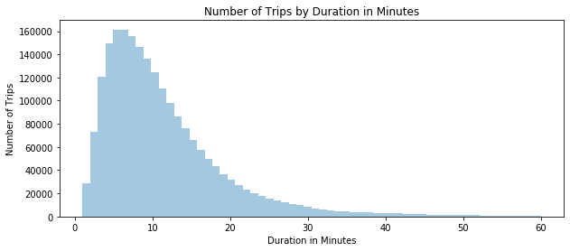

```python
import seaborn as sns

plt.figure(figsize=(10,4))
sns.distplot(df[df['duration_min']<60]['duration_min'], kde=False, bins=60)
plt.title("Number of Trips by Duration in Minutes")
plt.xlabel('Duration in Minutes')
plt.ylabel('Number of Trips');
plt.show()
```

#### Observation 2:

> Subscribers make up ~83% of all trips, while one-off customers make up ~17%.

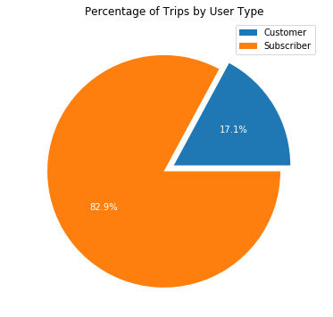

```python
total_trips = df['duration_sec'].count()
customer_trips = df[df['user_type']=='Customer']['duration_sec'].count() / total_trips
subscriber_trips = df[df['user_type']=='Subscriber']['duration_sec'].count() / total_trips

plt.figure(figsize=(6,6))
plt.pie([customer_trips,subscriber_trips], explode=(0, 0.1), labels=['Customer', 'Subscriber'],
        autopct='%1.1f%%', startangle=0, textprops={'color':'white'})
plt.title("Percentage of Trips by User Type")
plt.legend()
plt.show()
```

#### Observation 3:

> The graph below shows that most trips are done during weekdays which suggests that bike are mostly used for commuting from home to work or vice versa.

> To increase our confidence in this assumption, we need to check the trips by hour as well.

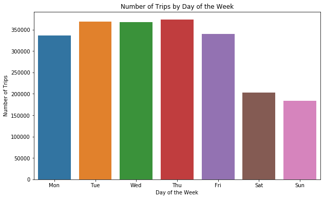

```python
day_order = ['Mon', 'Tue', 'Wed', 'Thu', 'Fri', 'Sat', 'Sun']

plt.figure(figsize=(10,6))
sns.countplot(x='start_time_day',data=df, order = day_order)
plt.title("Number of Trips by Day of the Week")
plt.xlabel('Day of the Week')
plt.ylabel('Number of Trips');
plt.show()
```

#### Observation 4:

> The visualisation below highlights peak trips occur at 8am and 5pm, potentially highlighting the GoBikes are being used to journey to and from resisential and work places.

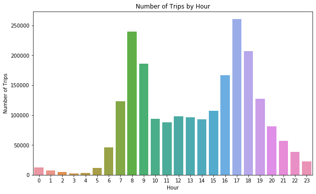

```python
plt.figure(figsize=(10,6))
sns.countplot(x='start_time_hour',data=df)
plt.title("Number of Trips by Hour")
plt.xlabel('Hour')
plt.ylabel('Number of Trips');
plt.show()
```

#### Observation 5:

> The number of trips by month shows that March and July are the peak months for trip, with May being the lowest. Removing the spike in trips during July and applying a hypothetical line of best fit from May to October, highlights a potential upward trend in trips by month.

> Further questions that emerge from this analysis are: Did GoBike initiate a marketing campaign at a certain time of the year or is the increase in volume of trips over the course of the year from May onwards (excluding July) organic?

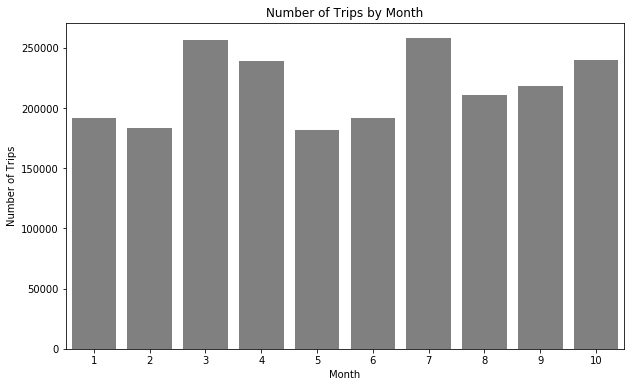

```python
plt.figure(figsize=(10,6))
sns.countplot(x='start_time_month',data=df, color='Grey')
plt.title("Number of Trips by Month")
plt.xlabel('Month')
plt.ylabel('Number of Trips');
plt.show()
```

### Discuss the distribution(s) of your variable(s) of interest. Were there any unusual points? Did you need to perform any transformations?

> The results of the analsysis indicate the GoBke system is likely used primarily for commuting during the week. These users tend to be majority subscribers. Weekend use of the GoBike system drops materially. No further transformations in the data were performed.

### Of the features you investigated, were there any unusual distributions? Did you perform any operations on the data to tidy, adjust, or change the form of the data? If so, why did you do this?

> One operation was performed to include trips that fell within a 1 hour duration. Few (immaterial) trips fell outside of this boundary and were classified as outliers.

> To avoid such trips being shown in the graph, I visualised trips of less than 1 hour.

## Bivariate Exploration

> Analysis of the pairplot data does not reveal obvious significant trends. Further analysis will be performed below to investigate bivariate relationships further.

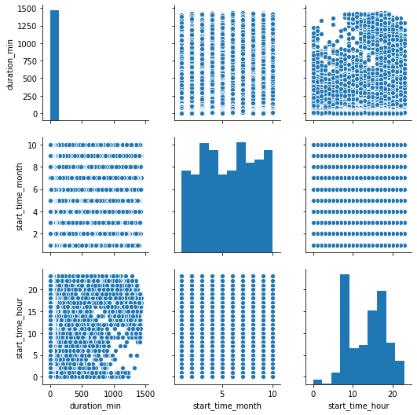

```python
data = df[['user_type','bike_share_for_all_trip','duration_min','start_time_month','start_time_hour','start_time_day']]

sns.pairplot(data)
```

### Observation 1

> The average trip tends to be approximately 10 minutes on average, with an uptick in trip duration at weekends.

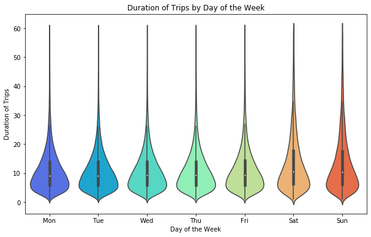

```python
day_order = ['Mon', 'Tue', 'Wed', 'Thu', 'Fri', 'Sat', 'Sun']

plt.figure(figsize=(10,6))
sns.violinplot(x='start_time_day', y='duration_min', data=df[df['duration_min']<60], palette='rainbow', order = day_order)
plt.title("Duration of Trips by Day of the Week")
plt.xlabel('Day of the Week')
plt.ylabel('Duration of Trips');
plt.show()
```

#### Observation 2

> In the following two graphs, the variation of trip duration between is analysed for by hour and by weekdays/weekends.

> The 1st graph shows that during weekdays longest trips are done at (03:00).

> During weekends, the trip duration peaks at approximately 14:00 - 15:00.

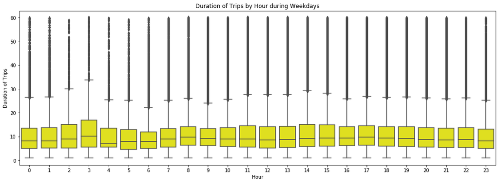

```python
data = df[(df['duration_min']<60) & (df['start_time_day']!='Sat') & (df['start_time_day']!='Sun')]

plt.figure(figsize=(18,6))
sns.boxplot(x='start_time_hour', y='duration_min', data=data, color='yellow')
plt.title("Duration of Trips by Hour during Weekdays")
plt.xlabel('Hour')
plt.ylabel('Duration of Trips');
plt.show()
```

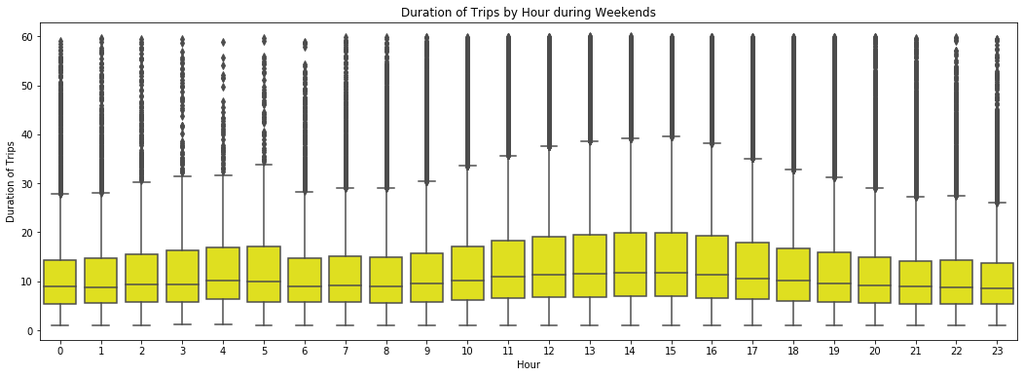

```python
data = df[(df['duration_min']<60) & ((df['start_time_day']=='Sat') | (df['start_time_day']=='Sun'))]

plt.figure(figsize=(18,6))
sns.boxplot(x='start_time_hour', y='duration_min', data=data, color='yellow')
plt.title("Duration of Trips by Hour during Weekends")
plt.xlabel('Hour')
plt.ylabel('Duration of Trips');
plt.show()
```

> The number of trips by hour during weekdays and weekends are defined below.

```python
df['week_period'] = df['start_time_day']

df.week_period = df.week_period.replace("Mon", "Weekday")
df.week_period = df.week_period.replace("Tue", "Weekday")
df.week_period = df.week_period.replace("Wed", "Weekday")
df.week_period = df.week_period.replace("Thu", "Weekday")
df.week_period = df.week_period.replace("Fri", "Weekday")

df.week_period = df.week_period.replace("Sat", "Weekend")
df.week_period = df.week_period.replace("Sun", "Weekend")

df.week_period.value_counts()
```

```
Weekday    1784874
Weekend     386511
Name: week_period, dtype: int64
```

#### Observation 3

> The results of the graphs below re-inforce the earlier analysis that peak trips are performed at the beginning and end of the working day.

> This highlights the GoBike system is largely used for commuiting purposes during the week and for leisure at the weekend.

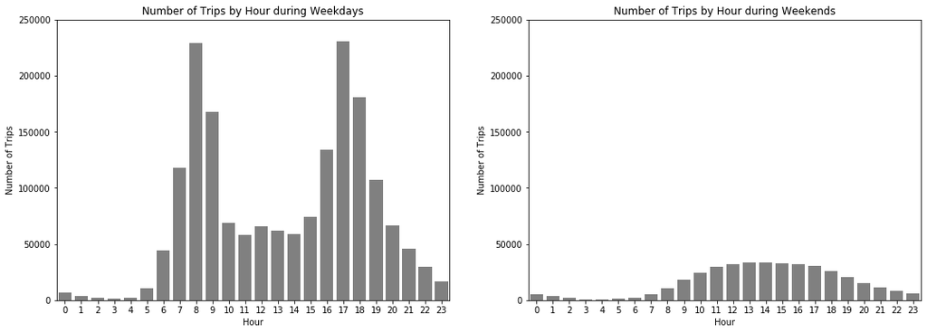

```python
plt.figure(figsize=(18,6))

plt.subplot(1, 2, 1) # 1 row, 2 cols, subplot 1
fig1 = sns.countplot(x='start_time_hour',data=df[df['week_period']=='Weekday'], color='Grey')
plt.title("Number of Trips by Hour during Weekdays")
plt.xlabel('Hour')
plt.ylabel('Number of Trips')
plt.ylim([0,250000])


plt.subplot(1, 2, 2) # 1 row, 2 cols, subplot 1
fig1 = sns.countplot(x='start_time_hour',data=df[df['week_period']=='Weekend'], color='Grey')
plt.title("Number of Trips by Hour during Weekends")
plt.xlabel('Hour')
plt.ylabel('Number of Trips')
plt.ylim([0,250000])
plt.show()
```

#### Observation 4

> Building on the earlier observation that trips overall began to increase from May to October (with July as a peak and exception), trips by month have been seperated across weekday and weekends.

> The increase in volume (on average) from May onwards appears to relate to weekday journeys only. Weekend trips show now consistent trend aside from peak use in March and fall in May.

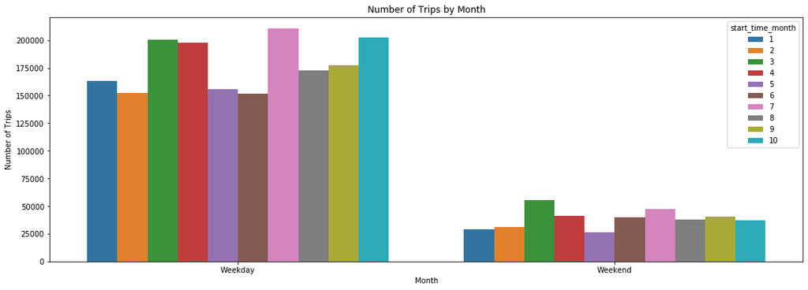

```python
plt.figure(figsize=(18,6))
sns.countplot(x='week_period',data=df, hue='start_time_month')
plt.title("Number of Trips by Month")
plt.xlabel('Month')
plt.ylabel('Number of Trips');
plt.show()
```

#### The variance of trip duration between the start and end stations is now analysed.

```python
# this function is to calculate the distance based on the latitude/longitude

# the code was copied form:
# https://stackoverflow.com/questions/19412462/getting-distance-between-two-points-based-on-latitude-longitude

from math import sin, cos, sqrt, atan2, radians

def distance (lat1,lon1,lat2,lon2):
    R = 6373.0

    lat1 = radians(lat1)
    lon1 = radians(lon1)
    lat2 = radians(lat2)
    lon2 = radians(lon2)

    dlon = lon2 - lon1
    dlat = lat2 - lat1

    a = sin(dlat / 2)**2 + cos(lat1) * cos(lat2) * sin(dlon / 2)**2
    c = 2 * atan2(sqrt(a), sqrt(1 - a))

    distance = R * c
    return np.float64(round(1000*distance)) # return distance in meters

# generating distance column using the defined function
df['distance'] = df.apply(lambda row: distance(row['start_station_latitude'],row['start_station_longitude'],row['end_station_latitude'],row['end_station_longitude']),axis=1)

df.head()
```

|  | bike_id | bike_share_for_all_trip | duration_sec | end_station_id | end_station_latitude | end_station_longitude | end_station_name | end_time | rental_access_method | start_station_id | ... | user_type | duration_min | duration_hour | start_time_month | start_time_hour | end_time_hour | start_time_day | Left_in_same_station | week_period | distance |
| --- | --- | --- | --- | --- | --- | --- | --- | --- | --- | --- | --- | --- | --- | --- | --- | --- | --- | --- | --- | --- | --- |
| 0 | 4861 | No | 80825 | 196.0 | 37.808894 | -122.256460 | Grand Ave at Perkins St | 2019-02-01 16:24:49.864 | NaN | 229.0 | ... | Subscriber | 1347.083333 | 22.451389 | 1 | 17 | 16 | Thu | No | Weekday | 5307.0 |
| 1 | 5506 | No | 65900 | 134.0 | 37.752428 | -122.420628 | Valencia St at 24th St | 2019-02-01 15:16:54.173 | NaN | 4.0 | ... | Subscriber | 1098.333333 | 18.305556 | 1 | 20 | 15 | Thu | No | Weekday | 3861.0 |
| 2 | 2717 | No | 62633 | 157.0 | 37.846784 | -122.291376 | 65th St at Hollis St | 2019-02-01 11:30:46.530 | NaN | 245.0 | ... | Customer | 1043.883333 | 17.398056 | 1 | 18 | 11 | Thu | No | Weekday | 3288.0 |
| 3 | 4557 | No | 44680 | 53.0 | 37.775946 | -122.437777 | Grove St at Divisadero | 2019-02-01 08:10:50.318 | NaN | 85.0 | ... | Customer | 744.666667 | 12.411111 | 1 | 19 | 8 | Thu | No | Weekday | 1000.0 |
| 4 | 2100 | No | 60709 | 28.0 | 37.787168 | -122.388098 | The Embarcadero at Bryant St | 2019-02-01 07:10:51.065 | NaN | 16.0 | ... | Customer | 1011.816667 | 16.863611 | 1 | 14 | 7 | Thu | No | Weekday | 954.0 |

5 rows × 24 columns

```python
df['distance'].describe()
```

```
count    2.171385e+06
mean     1.878527e+03
std      4.757588e+04
min      0.000000e+00
25%      9.290000e+02
50%      1.457000e+03
75%      2.241000e+03
max      1.280236e+07
Name: distance, dtype: float64
```

#### Observation 5

> It was anticipated the trip distance may be longer during the weekend and customers use the GpBike system for leisure purposes, unconstrained by factors such as a defined commute route.

> The average trip distance is higher during the weekday and marginally lower during the weekend, disproving this assumption.

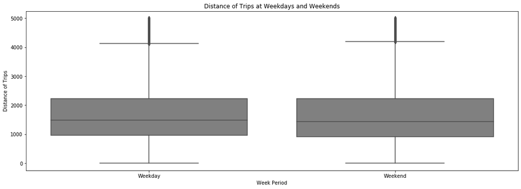

```python
data = df[(df['Left_in_same_station']=='No') & (df['distance']<5000)]

plt.figure(figsize=(18,6))
sns.boxplot(x="week_period", y="distance",data=data, color="grey")
plt.title("Distance of Trips at Weekdays and Weekends")
plt.xlabel('Week Period')
plt.ylabel('Distance of Trips');
plt.show()
```

### Talk about some of the relationships you observed in this part of the investigation. How did the feature(s) of interest vary with other features in the dataset?

> Peak volume trips are short in duration during weekdays. Users may be using it transit from one mode of transport to another, potentially a metro system.

> On the contrary trips are longer during weekends as people roam more freely. The variance between trip distance is broadly in line acorss weekdays and weekends.

### Did you observe any interesting relationships between the other features (not the main feature(s) of interest)?

> The number of trips during weekends are materially lower than during the week.

## Multivariate Exploration

#### Observation 1

> There was a material difference in trip volumes observed in July, compared to June and August. Both months are now analysed by weekday and weekend trip volume.

> The analysis below highlights te number of trips were similar at the beginning of the both months. During the week beginning 20th July, a material uptick in trip volumes occurs across a 7 day period.

> This raises further a further research questions: What caused the spike in demand for GoBikes during the week fo 20th to 27th July?

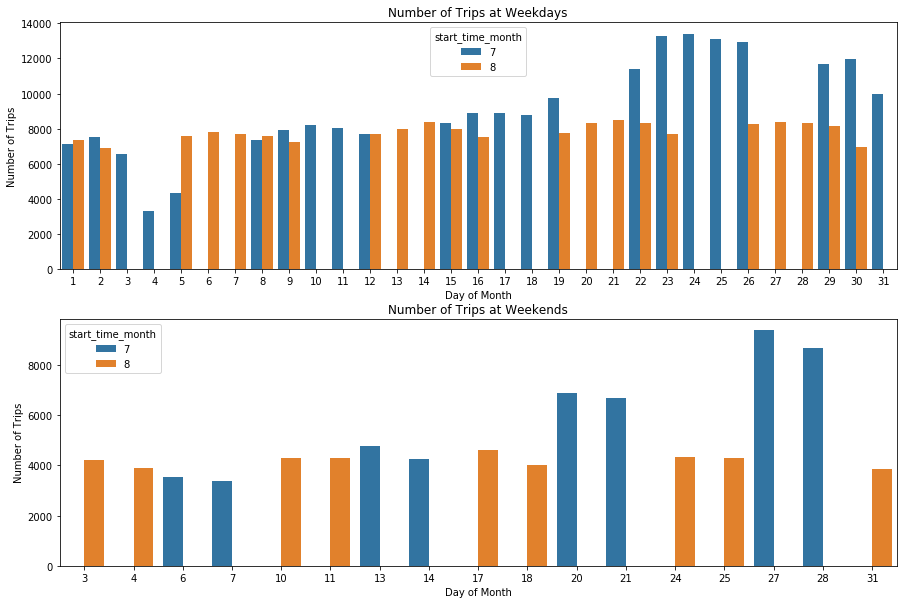

```python
data = df[((df['start_time_month'] == 7) | (df['start_time_month'] == 8))] #copying July and August data to a seperate dataframe

data['start_time_num_day'] = data['start_time'].dt.day.astype(int) #creating a day column


plt.figure(figsize=(15,10))

plt.subplot(2, 1, 1) # 2 rows, 1 col, subplot 1
sns.countplot(x='start_time_num_day',data=data[data['week_period']=='Weekday'], hue='start_time_month')
plt.title("Number of Trips at Weekdays")
plt.xlabel('Day of Month')
plt.ylabel('Number of Trips')

plt.subplot(2, 1, 2) # 2 rows, 1 col, subplot 1
sns.countplot(x='start_time_num_day',data=data[data['week_period']=='Weekend'], hue='start_time_month')
plt.title("Number of Trips at Weekends")
plt.xlabel('Day of Month')
plt.ylabel('Number of Trips')


plt.show()
```

#### Observation 2

> Trip duration, start time by day and start time by hour are illustrated below.

> Shortest trips appear to be around 06:00 - 07:00 when other traffic volumes may be low and increase marginally by 08:00, which we have earlier observed to be peak use volume during weekdays.

```python
data = pd.DataFrame(df.groupby(['start_time_day', 'start_time_hour']).mean()['duration_min'])
data = data.reset_index()
data.start_time_day = pd.Categorical(data.start_time_day,
                      categories=['Mon', 'Tue', 'Wed', 'Thu', 'Fri', 'Sat', 'Sun'],
                      ordered=True)
data.head()
```

|  | start_time_day | start_time_hour | duration_min |
| --- | --- | --- | --- |
| 0 | Fri | 0 | 14.567468 |
| 1 | Fri | 1 | 17.545046 |
| 2 | Fri | 2 | 18.640432 |
| 3 | Fri | 3 | 26.603140 |
| 4 | Fri | 4 | 16.370772 |

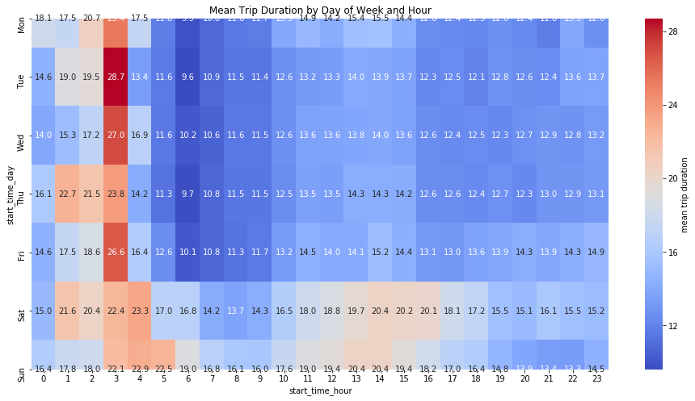

```python
pivot = data.pivot_table(values='duration_min',index='start_time_day',columns='start_time_hour')
plt.figure(figsize=(16,8))
sns.heatmap(pivot, annot=True, fmt='.1f', cbar_kws = {'label' : 'mean trip duration'}, cmap='coolwarm')
plt.title("Mean Trip Duration by Day of Week and Hour")
```

#### Observation 3

> Using latitude and longitue analysis, bike volumes are highest around the San Francisco Financial District.

> (Source) https://goo.gl/maps/TmTE3utq7435rNa9A

```python
data = df.copy()
data['start_station_latitude'] = data.start_station_latitude.round(3)
data['start_station_longitude'] = data.start_station_longitude.round(3)
data = pd.DataFrame(data.groupby(['start_station_latitude', 'start_station_longitude']).count()['duration_min'])
data = data.reset_index()
data.rename(columns={"start_station_latitude": "latitude",
                     "start_station_longitude": "longitude",
                     "duration_min": "number_of_trips"}, inplace=True)
data['longitude'] = data['longitude']+180
data.head()
```

|  | latitude | longitude | number_of_trips |
| --- | --- | --- | --- |
| 0 | 0.000 | 180.000 | 1 |
| 1 | 37.280 | 58.116 | 1 |
| 2 | 37.280 | 58.128 | 4 |
| 3 | 37.287 | 58.118 | 1 |
| 4 | 37.289 | 58.087 | 1 |

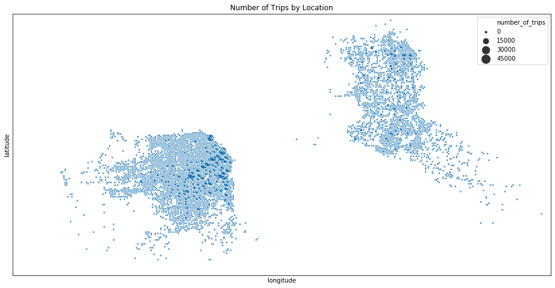

```python
plt.figure(figsize=(16,8))
sns.scatterplot(x="longitude", y="latitude", size="number_of_trips", sizes=(10, 200), data=data)
plt.ylim(37.7,37.9)
plt.xlim(57.45,57.85)
plt.title("Number of Trips by Location")
plt.yticks([])
plt.xticks([])
plt.legend()
```

### Were there any interesting or surprising interactions between features?

> Further research questions were raised:
> 1. Why did a peak in GoBike useage occur the week fo 20th July?
> 2. What is driving he growth of GoBike volume from May to October, excluding July?